# BCB420 Assignment 3

Justin Chee, 1002475136

## Dataset

**GEO ID:** GSE111972

**Dataset Name:** Transcriptional profiling of human microglia reveals grey-white matter heterogeneity and multiple sclerosis-associated changes

## Dataset Overview

GEO dataset was downloaded during the setup of the page.

Previously I had the opportunity to work with RNAseq data from brain samples and it was very interesting to examine the different expression profiles between different cell types in the brain especially in a diseased state. This dataset examines the expression profiles of both the grey matter and white matter of the human microglia in both healthy donors as well as donors with Multiple Sclerosis.

This data has been processed as seen in Assignment 1 and Assignment 2

```r
head(Meta(GSE))
```

```
## $contact_address
## [1] "Carl-Troll-Strasse 31"
##
## $contact_city
## [1] "Bonn"
##
## $contact_country
## [1] "Germany"
##
## $contact_department
## [1] "Genomics and Immunoregulation"
##
## $contact_email
## [1] "j.schultze@uni-bonn.de"
##
## $contact_institute
## [1] "LIMES (Life and Medical Sciences Center Genomics and Immunoregulation)"
```

**Title:** Illumina NextSeq 500 (Homo sapiens)

**Technology:** high-throughput sequencing

**Submission Date:** Apr 15 2014

**Last Update Date:** Mar 26 2019

**Organism:** Homo sapiens

**Number of GEO datasets that use this technology:** 3122

## Creating Rank files for GSEA

The processing used in Assignment 2 was used to create rank files for GSEA.

```r
# outputting rank files to use GSEA
write.table(x = qlf_output_hits_WM_gn[, c("x", "rank")],
            file = "WM_rank.rnk",sep = "\t",
            row.names = FALSE,col.names = FALSE,quote = FALSE)
write.table(x = qlf_output_hits_GM_gn[, c("x", "rank")],
            file = "GM_rank.rnk",sep = "\t",
            row.names = FALSE,col.names = FALSE,quote = FALSE)
```

## Running GSEA

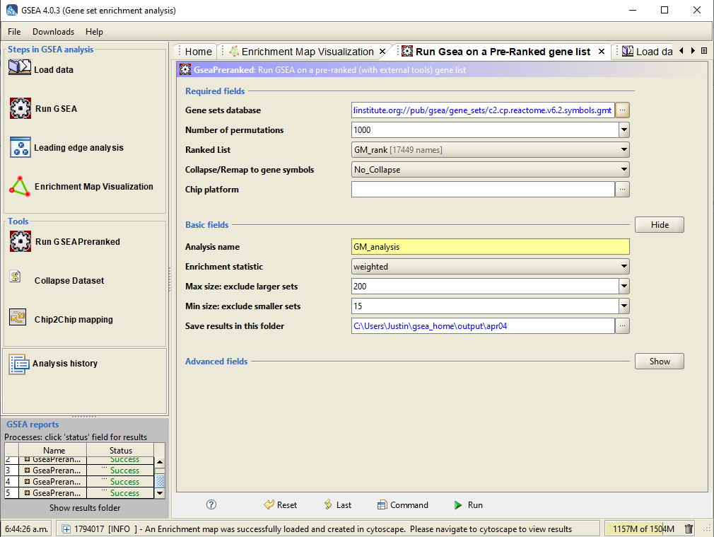

GSEA parameters used

This was done twice, once for the white matter expression data and once for the grey matter expression data.

**GSEA reports for white matter:**

### GSEA Report for Dataset WM_rank

#### Enrichment in phenotype: **na**

- 294 / 449 gene sets are upregulated in phenotype **na_pos**
- 50 gene sets are significant at FDR < 25%
- 36 gene sets are significantly enriched at nominal pvalue < 1%
- 60 gene sets are significantly enriched at nominal pvalue < 5%
- Snapshot of enrichment results
- Detailed enrichment results in html format
- Detailed enrichment results in excel format (tab delimited text)
- [Guide to](http://www.gsea-msigdb.org/gsea/doc/GSEAUserGuideFrame.html?_Interpreting_GSEA_Results) interpret results

#### Enrichment in phenotype: **na**

- 155 / 449 gene sets are upregulated in phenotype **na_neg**
- 0 gene sets are significantly enriched at FDR < 25%
- 3 gene sets are significantly enriched at nominal pvalue < 1%
- 13 gene sets are significantly enriched at nominal pvalue < 5%
- Snapshot of enrichment results
- Detailed enrichment results in html format
- Detailed enrichment results in excel format (tab delimited text)
- [Guide to](http://www.gsea-msigdb.org/gsea/doc/GSEAUserGuideFrame.html?_Interpreting_GSEA_Results) interpret results

#### Dataset details

- The dataset has 17449 features (genes)
- No probe set => gene symbol collapsing was requested, so all 17449 features were used

#### Gene set details

- Gene set size filters (min=15, max=200) resulted in filtering out 225 / 674 gene sets
- The remaining 449 gene sets were used in the analysis
- List of gene sets used and their sizes (restricted to features in the specified dataset)

#### Gene markers for the **na_pos** *versus* **na_neg** comparison

- The dataset has 17449 features (genes)
- Detailed rank ordered gene list for all features in the dataset

#### Global statistics and plots

- Plot of p-values *vs.* NES
- Global ES histogram

#### Other

- Parameters used for this analysis

#### Comments

- Timestamp used as the random seed: 1585995930291

Report: WM_analysis.GseaPreranked.1585995929439.rpt by user: Justin

xtools.gsea.GseaPreranked [Sat., Apr. 4, '20 6 a.m. 25]

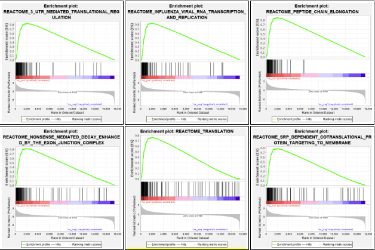

Several plots of positive enrichment results

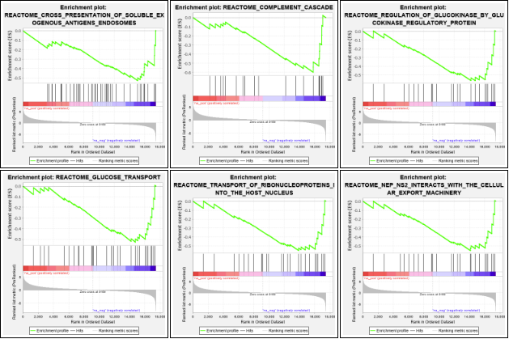

Several plots of negative enrichment results

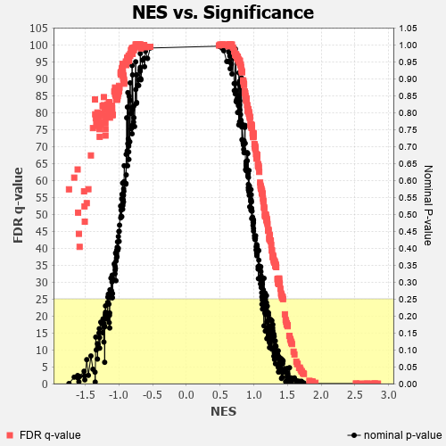

p-values vs NES

#### Dataset details

- The dataset has 17449 features (genes)
- No probe set => gene symbol collapsing was requested, so all 17449 features were used

#### Gene set details

- Gene set size filters (min=15, max=200) resulted in filtering out 225 / 674 gene sets
- The remaining 449 gene sets were used in the analysis
- List of gene sets used and their sizes (restricted to features in the specified dataset)

#### Gene markers for the **na_pos** *versus* **na_neg** comparison

- The dataset has 17449 features (genes)
- Detailed rank ordered gene list for all features in the dataset

#### Global statistics and plots

- Plot of p-values *vs.* NES
- Global ES histogram

#### Other

- Parameters used for this analysis

#### Comments

- Timestamp used as the random seed: 1585995930291

xtools.gsea.GseaPreranked [Sat., Apr. 4, '20 6 a.m. 25]

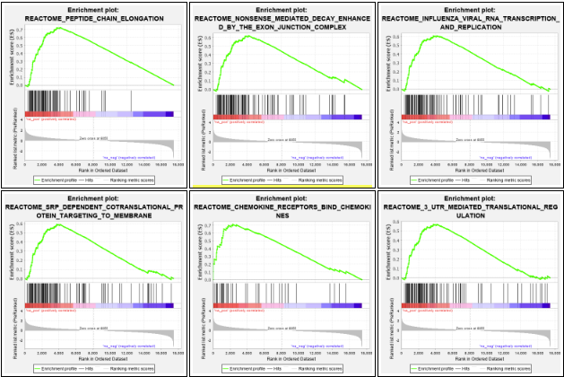

Several plots of positive enrichment results

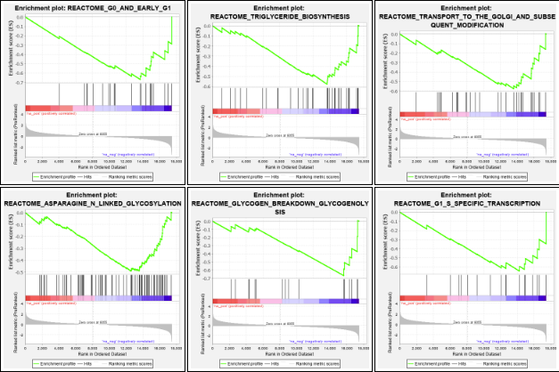

Several plots of negative enrichment results

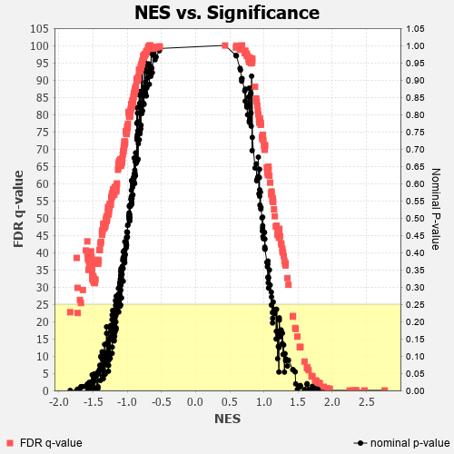

p-values vs NES

## Enrichment Map Visualization

[figure not shown]

Visualization of white matter network

[figure not shown]

Visualization of grey matter network

These results appear to be in line with the conclusions of the original paper.